# Desafios

## Hacerla de Jamón

Una tribu pacífica de la isla tiene un concurso legendario de jamones. El jurado es muy longevo y este año ha perdido a más de la mitad de sus miembros. La tribu te ha enviado una base de datos (*score_de_jamonosidad.csv*) de los últimos concursos. En esta base de datos se enlistan distintos especímenes de jamones con la calificación que el jurado otorgó a cada uno. También has recibido una base de datos de jamones no calificados (*jamones_por_calificar.csv*) que deberás calificar, honrando el espíritu del jurado. Para este desafío, puedes usar **R** o Python.

1. Explica con dibujos, diagramas, ecuaciones, etc tu modelo.
2. Implementa tu modelo indicando los comandos que usas.
3. Completa el archivo jamones_por_calificar.csv con tu veredicto.

El reto pide primero explicar el modelo con dibujos, diagramas, ecuaciones, etc. Para poder hacer eso, lo primero es saber que modelo se va a ocupar y uno no sabe que modelo es el que dara mejor respuesta a un problema hasta que hace un análisis exploratorio de los datos y se da una idea general de ellos. Realicemos primero este análisis.

#### Análisis exploratorio de los datos

```r
df <- read.csv("data_frames/Copia de score_de_jamonosidad.csv")
summary(df)
```

```
##      jamon           score              v1             v2
##  Min.   : 1.00   Min.   : 0.000   Min.   :1414   Min.   :43.80
##  1st Qu.: 7.75   1st Qu.: 4.000   1st Qu.:1714   1st Qu.:54.77
##  Median :14.50   Median : 6.500   Median :2106   Median :58.85
##  Mean   :14.50   Mean   : 6.964   Mean   :2127   Mean   :58.30
##  3rd Qu.:21.25   3rd Qu.:10.000   3rd Qu.:2474   3rd Qu.:61.10
##  Max.   :28.00   Max.   :13.000   Max.   :2929   Max.   :68.50
##        v3
##  Min.   :1457
##  1st Qu.:1888
##  Median :2062
##  Mean   :2133
##  3rd Qu.:2427
##  Max.   :2876
```

Vemos que contamos con 5 variables, todas numericas, la primer variable tiene el nombre *jamon* por lo que seguramente es el id asignado a cada uno de los jamones evaluados, la segunda variable *score* corresponde a la calificación asignada a cada jamon, es la variable a modelar. Las variables *v1*, *v2* y *v3* representan atributos numericos de cada jamon en base a los cuales debemos determinar su *score*.

Veamos un poco más como se comportan los datos.

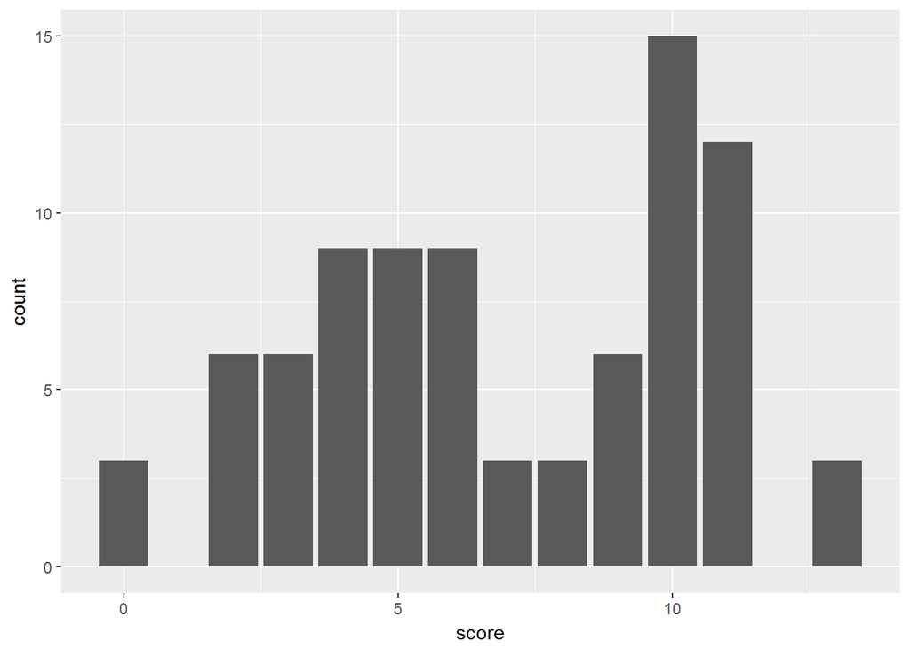

La variable *score* es discreta y toma valores desde 0 hasta 13, el valor con más apariciones es 10 y su media es 6.9.

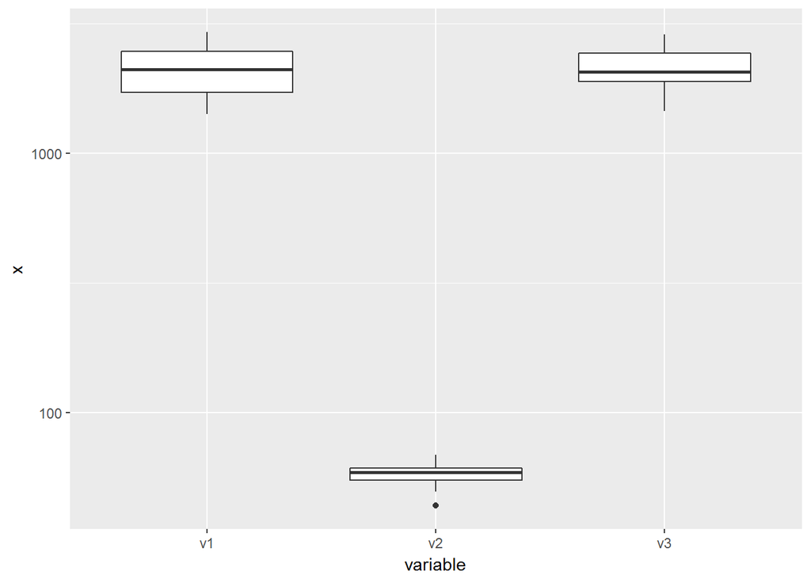

```r
ggplot(tidy, aes(y=x, x=variable)) + geom_boxplot() + scale_y_log10()
```

Busquemos si existe alguna correlación entre las variables que queremos utilizar para crear el modelo.

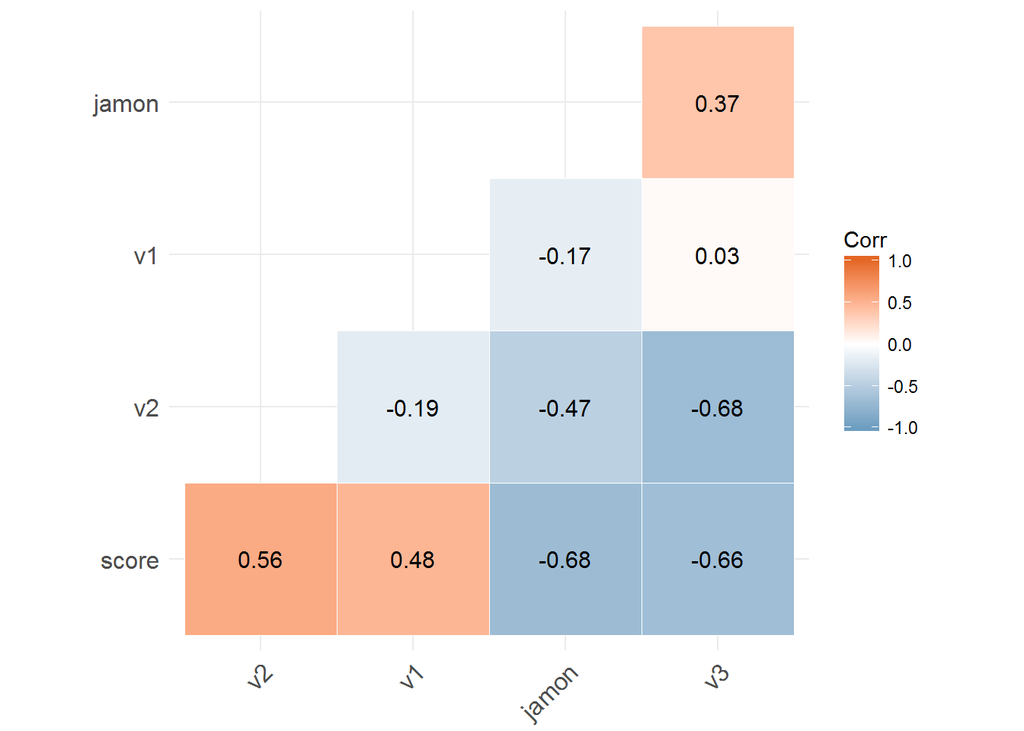

```r
corr <- round(cor(df), 3)
ggcorrplot(corr, hc.order = TRUE, lab=TRUE, type="lower",
   outline.col = "white",
   colors = c("#6D9EC1", "white", "#E46726"))
```

La correlación entre *v2* y *v3* es más alta de lo ideal, sin embargo, la que existe entre *v3* y *v1* es cercana a 0 y tambien lo es la existente entre *v1* y *v2*.

### Clasificación

Tomemos el 80% de las observaciones en el dataframe como set de entrenamiento. Preparemos los argumentos que recibirá la función *knn()*

```r
set.seed(1234)
train <- sample(1:28, size=round(0.8*28, 0), replace = FALSE)
test <- c(1:28)[-train]
train_set <- df[train, c("v1", "v2", "v3")]
test_set <- df[test, c("v1", "v2", "v3")]
train_scores <- df[train, "score"]
test_scores <- df[test, "score"]
```

```r
set.seed(1234)
knn_pred <- knn(train_set, test_set, train_scores, k=13)
table(knn_pred, test_scores)
```

```
##         test_scores
## knn_pred 2 3 4 10 11
##       0  0 0 0  0  0
##       2  0 0 0  0  0
##       3  0 0 0  0  0
##       4  0 0 0  0  0
##       5  1 0 0  0  0
##       6  0 1 0  1  1
##       7  0 0 0  0  0
##       8  0 0 0  0  0
##       9  0 0 0  0  0
##       10 0 0 1  1  0
##       11 0 0 0  0  0
##       13 0 0 0  0  0
```

```r
mse_knn <- mean((as.numeric(knn_pred)- test_scores)^2)
```

Intentemos utilizar un modelo de regresión lineal.

```r
lm_model <- lm(score ~ v1 + v2 + v3, data=df[train, ])
lm_pred <- predict(lm_model, test_set)
mse <- mean(((lm_pred - test_scores)^2))
```

```r
lm_model_0 <- lm(score ~ 0 + v1 + v2 + v3, data=df[train, ])
lm_pred_0 <- predict(lm_model_0, test_set)
mse_0 <- mean(((lm_pred_0 - test_scores)^2))
```

Modelo utilizando Linear Discriminant Analysis

```r
lda_fit <- lda(score ~ v1 + v2 + v3, data=df, subset = train)
lda_pred <- predict(lda_fit, test_set)
mse_lda <- mean(((as.numeric(lda_pred$class) - test_scores)^2))
```

```r
final_model <- lda(score ~ v1 + v2 + v3, data=df)
```

Realizemos las predicciones de los datos en el archivo de jamones por calificar.

```r
prediction_df <- read.csv("data_frames/Copia de jamones_por_calificar.csv")
prediction <- predict(final_model, prediction_df[,c("v1", "v2", "v3")])
```

guardemos las predicciones en archivo.

```r
prediction_df$score <- as.numeric(prediction$class)
write.csv(prediction_df, "results/jamones_calificados_lda.csv", row.names = FALSE)
```